# Bayesian Network - Data Science Capstone

Author

Maxime MARTIN

Published

June 28, 2024

## Paper review

### 1) A single Bayesian Network classifier for monitoring with unknown classes

Date: 2019

Ref : Atoui et al. (2019)

The authors investigate the use of BN to create a classifier for monitoring systems with unknown classes. They employ Conditional Gaussian Networks (CGN), where each node represents either a discrete or Gaussian random variable linked to multivariate random variables (RV). Their approach involves graphical analysis and a quadratic statistic to determine the class of each multivariate observation, utilizing a control limit (CL) for classification.

The paper delves into detailed analysis, providing insights into the fault detection and diagnosis algorithm, including exclusion criteria. Various structures are explored, such as simpler BN structures and their association with CGN. The effectiveness of the proposed system is demonstrated and evaluated using the complex Tennessee Eastman Process (TEP).

Further research is suggested to expand the proposed approach to other data-driven CGN, develop new algorithms to handle multiple faults, and explore more complex BN structures for integration.

### 2) Application of Bayesian Networks in Reliability Evaluation

Ref : Cai et al. (2020)

The authors review the use of BN over the past decades, highlighting their strengths in modeling complex systems and handling uncertainties. Like comprehensive review of the industrial application in reliability field. The new feature introduced in the paper is a classification framework for BN in reliability evaluation. This framework categorises BN based on the objects of reliability evaluation (hardware, software), which provides a structured approach to applying BN across various industrial contexts. This systematic classification helps in better understanding and implementing BN for different reliability evaluation tasks, enhancing the practical application and effectiveness of BN in real-world scenarios.

The paper discusses various case studies, demonstrating the practical implementation of BN in different industrial contexts. However, there are some limitations, first the accuracy of BN heavily relies on the availability of sufficient and high-quality data, which can be a significant constraint. Second, applying BN to very large and complex systems poses computational challenges, making it difficult to manage and analyse such systems effectively. Third, there is a need for further research to integrate BN with other reliability evaluation methods, which could enhance their accuracy and applicability in diverse industrial contexts. Addressing these limitations is essential for improving the practical use of BN in reliability assessments.

### 3) Rational Irrationality: Modeling Climate Change Belief Polarization Using Bayesian Networks

Authors: J. Cook, S. Lewandowsky

Date: 2016

Ref : Cook and Lewandowsky (2016)

This paper examines belief polarization, which occurs when two individuals interpret the same evidence and update their beliefs in opposite directions. This phenomenon represents the irrational aspect of the study. The researchers use Bayesian networks to simulate belief polarization, representing the rational aspect.

The study focuses on climate change beliefs in two countries, Australia and the USA. Four groups of variables were used to illustrate different factors: W (worldview/free market support), T (trust in climate scientists), H (belief in human-caused global warming), and E (evidence from scientific consensus). The relationships between these variables are modeled as follows: W-T, W-H, T-E, H-E.

The aim was to determine if individuals with different worldviews (W) exhibit belief polarization when presented with scientific evidence, considering varying levels of trust in climate scientists and belief in human-caused global warming.

Data analysis was conducted using R, modeling ANOVA tests for each variable combination. Significant differences were found between the two countries. Bayesian networks were then fitted to each country’s data, resulting in unique sets of Bayesian network parameters for each.

The study found that worldview is a dominant influence on climate beliefs and that providing consensus information increases the perception of consensus. Among U.S. participants, the consensus intervention led to increased distrust in scientists among those with a particular worldview when informed about the scientific consensus.

A limitation of the study is the small effect sizes of the experimental manipulation compared to the large effect of worldview, which may be due to the brief nature of the manipulation.

### 4) *** Quantifying and predicting the Water-Energy-Food-Economy-Society- Environment Nexus based on Bayesian networks - A case study of China

Authors: J. Chai, H. Shi, Q. Lu, Y. Hu

Date: 2020

Ref : Chai et al. (2020)

This paper is an application of bayesian networks into a real life problem in China. The complex problem is modeled from a Nexus inspiration where the core nexus is a vertual circle between water, food and energy. Then the second, peripheral nexus are climate, population and Trade which will feed the first core nexus. The goal of the paper is to model that Nexus using Bayesian networks in order to know what are the causal relationships and how stong they are. Then it’s also possible to make some simulation about the future based on some study from united nations or other official publisher.

They used an already existed Nexus with the following variables :

GDP growth rate (Economy), Population growth rate (Social), Annual rainfall (Environmental), Water resource stock and water intake (Water), Energy consumption growth rate and Energy production growth rate (Energy), Food demand growth rate and Food production growth rate (Food).

From “expert knowledge” they could define the relationship between the different variable. And then from a discretization of the data, the were able to fill the states created (3 states for each evidence variable). After modeling everything in a Bayesian network, there were able to answer all their question and even making forecast on the water withdrawal, energy demand and food demand given all the resources from the other variables.

The limitations are that the relationships between the variables of the nexus are not static but dynamic, they used a classic Bayesian network than cannot handle dynamic relationships. And the predicted values are intervals and not “precised values”. The precision here could be improved by more indicators implemented in the Nexus.

### 5) Applications of Bayesian networks and Petri nets in safety, reliability, and risk assessments: A review

Authors: S. Kabir, Y. Papadopoulos

Date: 2019

Ref : Kabir and Papadopoulos (2019)

This paper is a review of how to prevent risk by controlling the parameter of reliability and risk assessments in complex systems by using Bayesian networks and Petri nets. Even if half of the paper will be on petri nets, it’s interesting to see the link between those two methods. We can also mention the use of markov chain to do the same surveillance. It also explain the links between other methods to Bayesian networks, for example how to go from a fault tree to a Bayesian network (the mapping process).

It’s re-explaining the advantages of Bayesian networks and why using them in a problem related to safety and risk assessment. The main advantage of Bayesian networks over the other existing approaches is their polyvalency, they can offer different functionality such as predictive and diagnostic analysis model, updating, and optimization. Also, Bayesian network can applied both discrete and continuous model of time.

They also explain the process of creation of a Bayesian network, following these steps:

I. Identify variables -> identify network structure -> Express as statistical variables

II. Specify conditional probabilities

III. Enter evidence -> Propagate -> Interprete results

The major limitations of Bayesian network aplications are that the guideline we use to create the nodes will define the result at the end, so to ensure a coherent model we should take care of the few first steps. Also, if the parent-child relationships are not properly defined, the model can be more complex to analyse.

## Analysis and Results

### Loading the data

```r
asia<- bnlearn::asia
```

### Writing the model

Rearanging the data and plotting the relationship between the parameters.

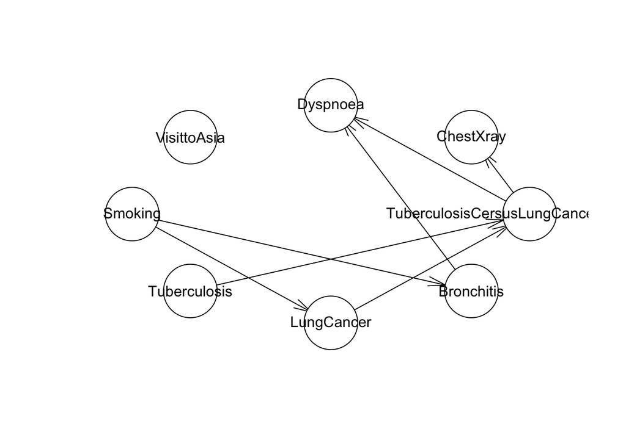

```r
colnames(asia) <- c("VisittoAsia","Smoking","Tuberculosis","LungCancer","Bronchitis", "TuberculosisCersusLungCancer_Bronchitis",
                      "ChestXray","Dyspnoea")

bn_df <- data.frame(asia)
res <- hc(bn_df)
plot(res)
```

### Rewrite the model and plot it

We will rewrite the model with new informations we have. And we will plot again the results.

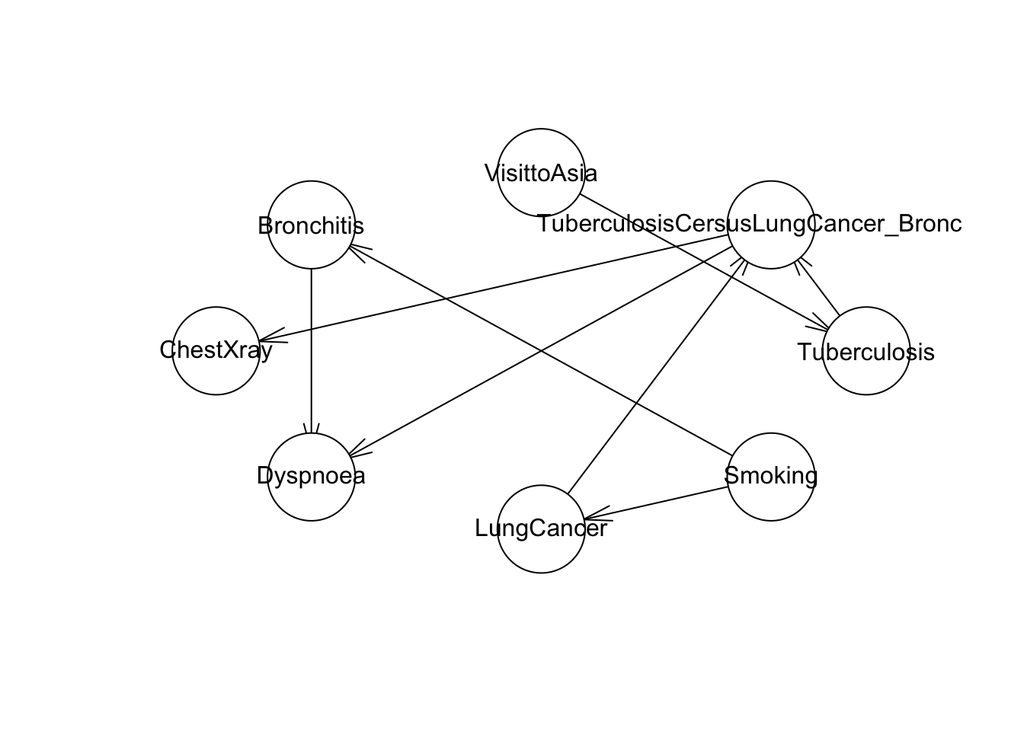

```r
res = model2network("[VisittoAsia][Smoking][Tuberculosis|VisittoAsia][LungCancer|Smoking][Bronchitis|Smoking][Dyspnoea|Bronchitis:TuberculosisCersusLungCancer_Bronchitis][TuberculosisCersusLungCancer_Bronchitis|Tuberculosis:LungCancer][ChestXray|TuberculosisCersusLungCancer_Bronchitis]")

#res <- hc(bn_df)
plot(res)
```

Visit to asia is alone, means that there is nothing pointed to it. Same for Smoking because it’s only a parent node.

Tuberculosis|VisittoAsia means that Tuberculosis is influenced by visit to asia.

etc .. etc…

### Fit the model to our data

Now we will fit the model we have to our data

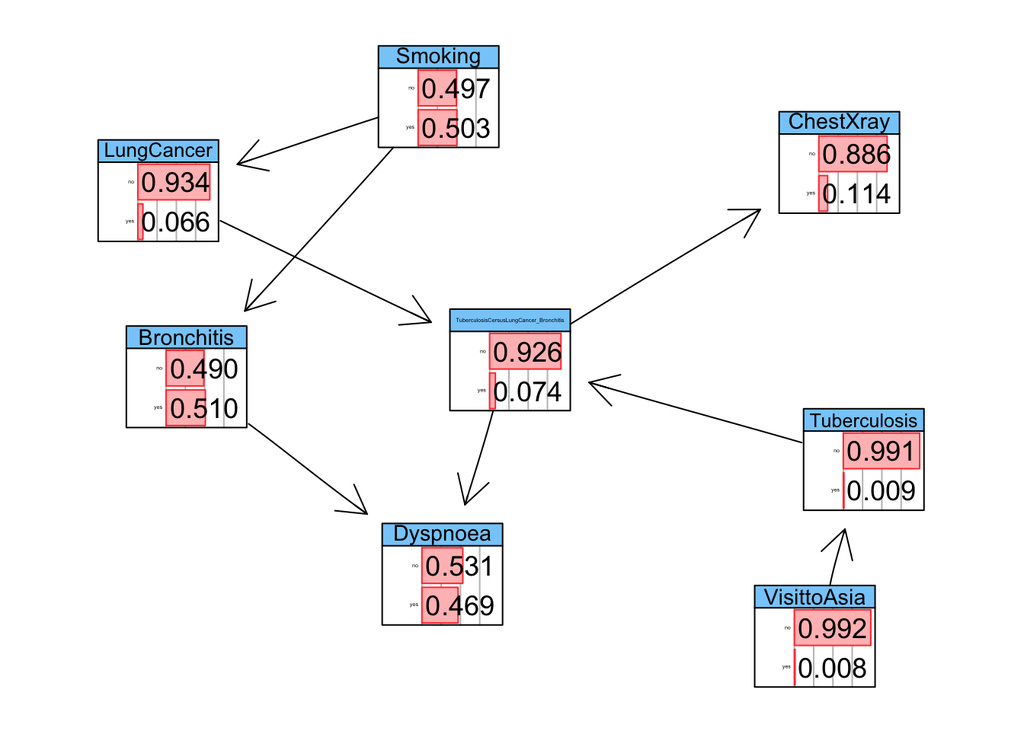

```r
fittedbn <- bn.fit(res, data = bn_df)

graphviz.chart(
  fittedbn,
  type = "barprob" ,
  layout = "fdp",
  scale = c(0.75, 0.9),
  grid = TRUE,
  bar.col = "red",
  strip.bg = "lightskyblue"
)
```

```r
fittedbn <- bn.fit(res, data = bn_df)

print(fittedbn$Tuberculosis)
```

```
  Parameters of node Tuberculosis (multinomial distribution)

Conditional probability table:

            VisittoAsia
Tuberculosis          no         yes
         no  0.991528842 0.952380952
         yes 0.008471158 0.047619048
```

```r
print(fittedbn$TuberculosisCersusLungCancer_Bronchitis)
```

```
  Parameters of node TuberculosisCersusLungCancer_Bronchitis (multinomial distribution)

Conditional probability table:

, , Tuberculosis = no

                                       LungCancer
TuberculosisCersusLungCancer_Bronchitis no yes
                                    no   1   0
                                    yes  0   1

, , Tuberculosis = yes

                                       LungCancer
TuberculosisCersusLungCancer_Bronchitis no yes
                                    no   0   0
                                    yes  1   1
```

```r
cpquery(fittedbn, event = (Smoking=="yes"), evidence = (Bronchitis=="no"))
```

```
[1] 0.3015742
```

```r
print(fittedbn$Tuberculosis)
```

```
  Parameters of node Tuberculosis (multinomial distribution)

Conditional probability table:

            VisittoAsia
Tuberculosis          no         yes
         no  0.991528842 0.952380952
         yes 0.008471158 0.047619048
```

```r
fittedbn[["Bronchitis"]]
```

```
  Parameters of node Bronchitis (multinomial distribution)

Conditional probability table:

          Smoking
Bronchitis        no       yes
       no  0.7006036 0.2823062
       yes 0.2993964 0.7176938
```

## References

Atoui, M. Amine, Achraf Cohen, Sylvain Verron, and Abdessamad Kobi. 2019. “A Single Bayesian Network Classifier for Monitoring with Unknown Classes.” *Engineering Applications of Artificial Intelligence* 85: 681–90. https://doi.org/https://doi.org/10.1016/j.engappai.2019.07.016.

Cai, Baoping, Yonghong Liu, Zengkai Liu, Yuanjiang Chang, and Lei Jiang. 2020. “Application of Bayesian Networks in Reliability Evaluation.” In *Bayesian Networks for Reliability Engineering*, 1–25. Singapore: Springer Singapore. https://doi.org/10.1007/978-981-13-6516-4_1.

Chai, Jian, Huiting Shi, Quanying Lu, and Yi Hu. 2020. “Quantifying and Predicting the Water-Energy-Food-Economy-Society-Environment Nexus Based on Bayesian Networks - a Case Study of China.” *Journal of Cleaner Production* 256: 120266. https://doi.org/https://doi.org/10.1016/j.jclepro.2020.120266.

Cook, John, and Stephan Lewandowsky. 2016. “Rational Irrationality: Modeling Climate Change Belief Polarization Using Bayesian Networks.” *Topics in Cognitive Science* 8 (1): 160–79. https://doi.org/https://doi.org/10.1111/tops.12186.

Kabir, Sohag, and Yiannis Papadopoulos. 2019. “Applications of Bayesian Networks and Petri Nets in Safety, Reliability, and Risk Assessments: A Review.” *Safety Science* 115: 154–75. https://doi.org/https://doi.org/10.1016/j.ssci.2019.02.009.